# **Analysis script**

#### Paper ID: Christensen_EurJournPersonality_2018_8R9d

#### Researcher ID: QL2M7

**Testing claim:** … the high openness to experience group’s network was more interconnected …  
than the low openness to experience group (p. 480.)

### **1. Data preprocessing**

##### *1.1 Loading packages*

```r
#Loading R packages
library(dplyr)
library(psych)
library(PerformanceAnalytics)
library(visdat)
library(SemNetDictionaries)
library(SemNetCleaner)
library(SemNeT)
```

##### *1.2 Data import*

Importing an original dataset from [OSF repositary](https://osf.io/6zh34/?view_only=3e5bfed2e1f041dbbb4376e9c0c5f70b)

```r
# Importing data
data <- as.data.frame(read.csv2("C:\\Users\\cyril\\Desktop\\Научная работа\\Написание научных публикаций\\Статья №19. Проект Multi100\\4. Анализ\\FINAL demo open fluency.csv"))
```

##### *1.3 Omitting nedless columns*

Only columns corresponding to ID, sample, openness to experience, and verbal fluency were retained.

```r
# Preserving variables relevant for the analysis
column_names <- as.data.frame(colnames(data))
data <- data %>%
  select(column_names[c(1:2,13:15,18:67),])
```

### **2. Splitting sample on “low” and “high” level of openness**

##### *2.1 Examining inter-correlations among openness measures*

Our primary task was to divide participants from three samples into two groups: “low” and “high” openness to experience. Given that there were from 2 to 3 total scores for openness to experience for each sample (*methods*: NEO-PI-3, NEO-FFI-3, and BFAS), we started with computing correlation matrix to inform further decisions.

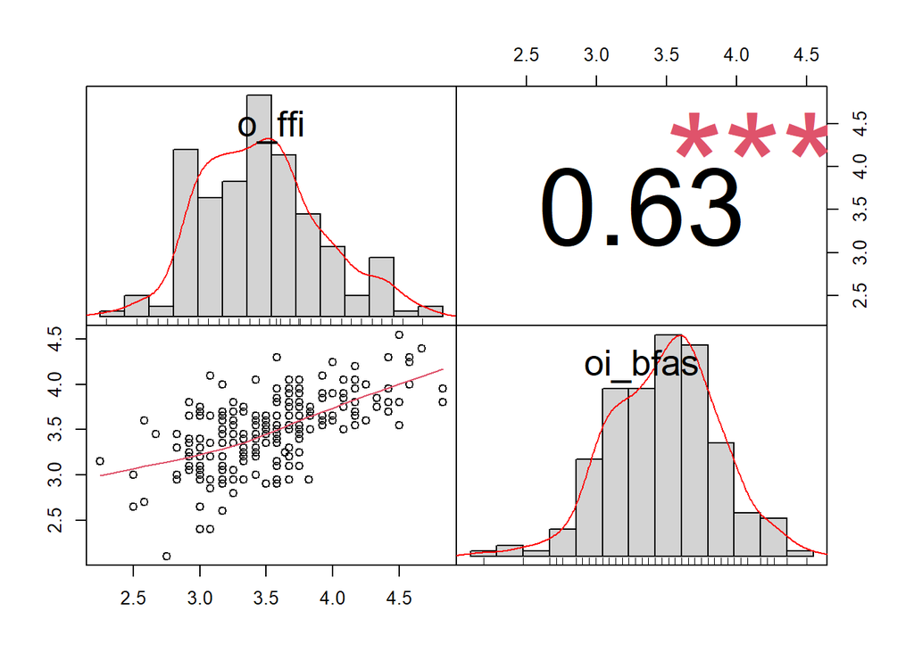

```r
# Storing openness scores for each sample separately
sample_1 <- data %>% filter(Sample == 1) %>% select(id, o_ffi, oi_bfas)
sample_2 <- data %>% filter(Sample == 2) %>% select(id, o_ffi, oi_bfas, o_neo)
sample_3 <- data %>% filter(Sample == 3) %>% select(id, o_ffi, oi_bfas)

# Visualizing correlation matrix for the 1st sample
chart.Correlation(sample_1[,-1], histogram=TRUE, pch=19)
```

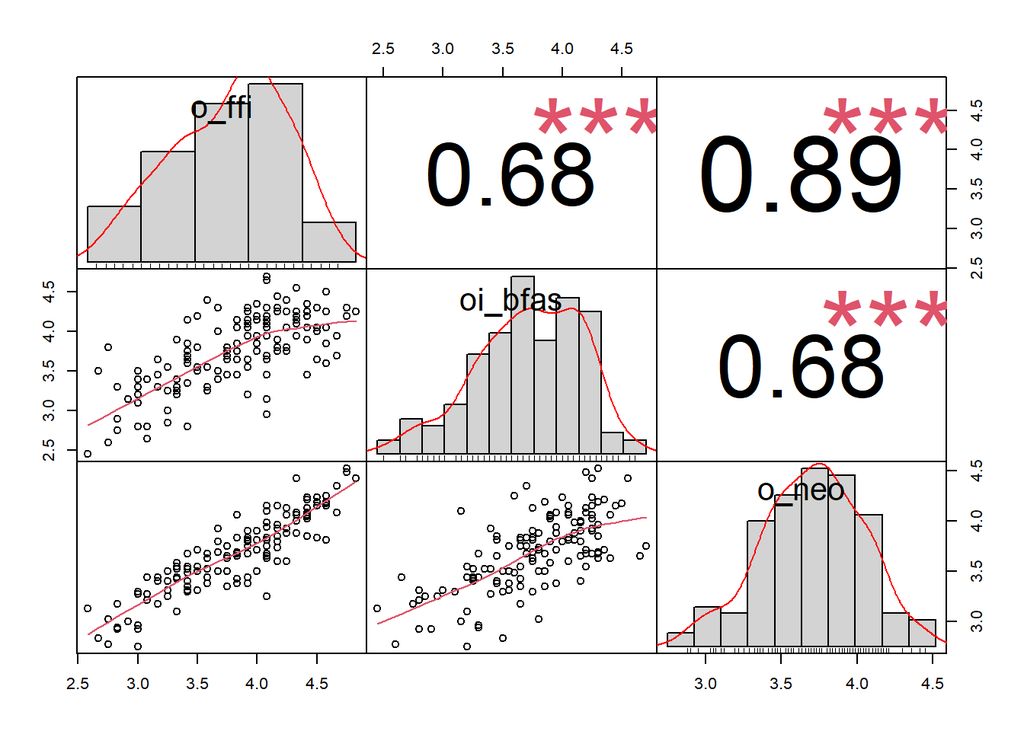

```r
# Visualizing correlation matrix for the 2nd sample
chart.Correlation(sample_2[,-1], histogram=TRUE, pch=19)
```

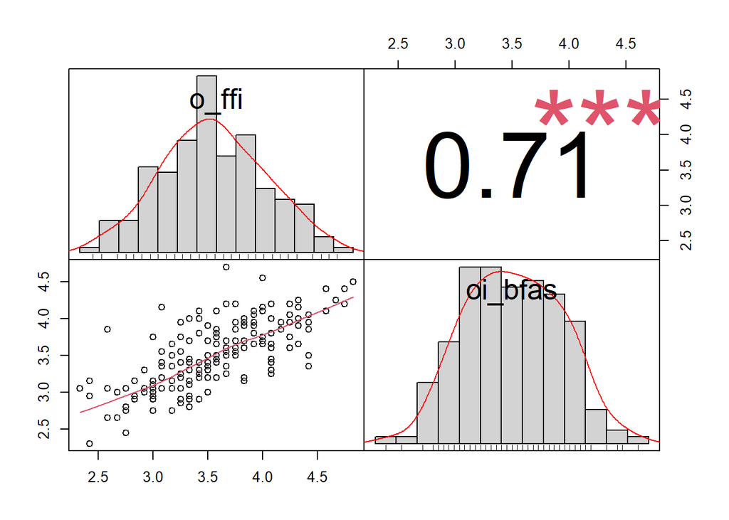

```r
# Visualizing correlation matrix for the 3rd sample
chart.Correlation(sample_3[,-1], histogram=TRUE, pch=19)
```

```r
# Bounding rows of the 1st and 3rd samples because in both samples openness was
# measured with two methods (NEO-FFI-3 and BFAS; i.e., these sample can be merged
# together), while in the 2nd sample openness was measured with three methods
# (NEO-PI-3, NEO-FFI-3, and BFAS)
sample_1_3 <- rbind(sample_1, sample_3)
```

##### *2.2 Factor analysis of openness measures*

Results for all openness to experience measures across samples have been highly correlated. Thus, we decided to conduct exploratory factor analysis (EFA) and to extract estimated factor scores. After that, we combined all factor scores in one numeric vector and merged it with the original dataset.

```r
# Computing factor analysis in both samples 1-3 and 2
openness_FA_sample_1_3 <- fa(sample_1_3, nfactors = 1, fm = "pa", correct = FALSE)
openness_FA_sample_2 <- fa(sample_2, nfactors = 1, fm = "pa", correct = FALSE)

# Estimating and saving factor scores for openness in sample 1-3
openness_scores_sample_1_3 <- factor.scores(sample_1_3,openness_FA_sample_1_3, method="Bartlett")
openness_scores_sample_1_3 <- as.data.frame(cbind(sample_1_3$id,openness_scores_sample_1_3$scores))

# Estimating and saving factor scores for openness in sample 2
openness_scores_sample_2 <- factor.scores(sample_2,openness_FA_sample_2, method="Bartlett")
openness_scores_sample_2 <- as.data.frame(cbind(sample_2$id,openness_scores_sample_2$scores))

# Binding factor scores across samples together, renaming columns, and attaching factor scores to the initial dataset
openness_FA <- rbind(openness_scores_sample_1_3, openness_scores_sample_2)
colnames(openness_FA) <- c("id", "openness")
openness_FA <- openness_FA %>% arrange(id)
data$openness_FA <- openness_FA$openness
```

##### *2.3 Grouping participants to “low” and “high” openness group*

Next, we calculated median for factor scores of openness and divided participants into two groups based on whether their factor score was below (“low” openness group) or above the median (“high” openness group).

```r
# Computing median for factor scores of openness
median_openness <- median(as.numeric(data$openness_FA))

# Splitting sample on "low" and "high" level of openness by median
data <- data %>% mutate(group = if_else(openness_FA < median_openness, 1, 2))
```

### **3. Network analysis for verbal fluency (VF)**

##### *3.1 Extracting data*

Now we turn to building network models for verbal fluency (VF) task separately for “low” and “high” openness groups.

```r
# Reorganizing data to include only verbal fluency responses
VF_responses <- data[,c(6:55)]
```

##### *3.2 Сhecking missing data*

First, we examined the pattern of missing values for VF responses.

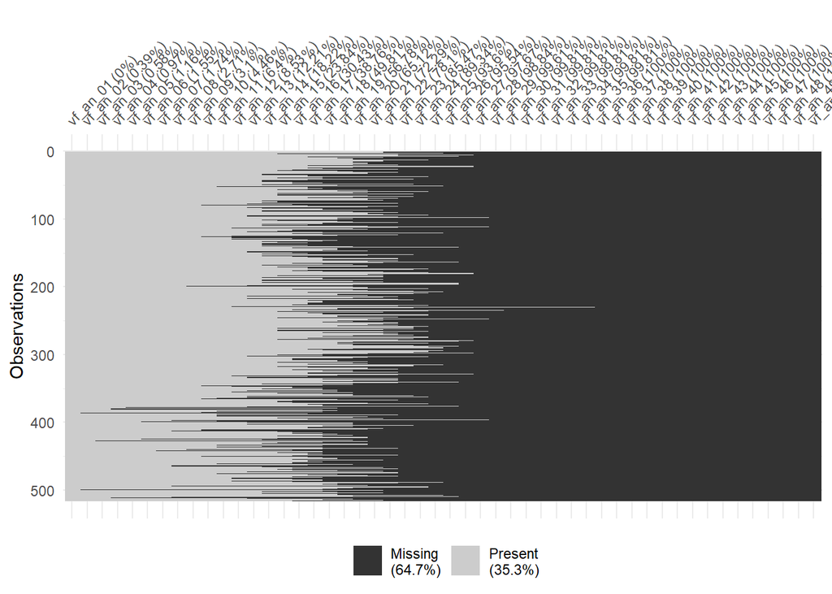

```r
# Visualizing missing values
missing_values <- VF_responses
missing_values[missing_values == 99] <- NA
vis_miss(missing_values)
```

Since nobody offered more than 35 answers, only the first 35 answers were used in further data pre-processing.

```r
# Retaining responses from the 1st to the 35th
VF_responses <- VF_responses[,c(1:35)]
```

##### *3.3 Cleaning and correcting responses*

Second, VF responses passed through text-cleaning procedure to correct errors, typos, etc., and removing bad strings or responses.

```r
# Cleaning VF data and transforming data into binary matrix
clean <- textcleaner(data = VF_responses, miss = 99, partBY = "row", dictionary = "animals")
```

Since the text-cleaning procedure runs semi-automatically in the R console, the cleared data were saved in a separate .csv file and uploaded in the form of a new dataframe so that to keep the code as simple and clear as possible.

```r
# Loading already cleaned data
cleaned_VF <- as.data.frame(read.csv2("C:\\Users\\cyril\\Desktop\\Научная работа\\Написание научных публикаций\\Статья №19. Проект Multi100\\4. Анализ\\Cleaned_VF_binary_2.csv"))
```

##### *3.4 Merging grouping variable and pre-processed VF data*

Third, already cleaned data for VF was joined with the grouping variable (1 = “*low openness*”, 2 = “*high openness*”).

```r
# Merging grouping variable (i.e., openness) and cleaned VF responses in a binary form
verbal_fluency <- as.data.frame(cbind(group = data[,57], cleaned_VF))
```

##### *3.5 Splitting VF data for “low” and “high” openness groups*

Fourth, we divided the dataset into two based on the grouping variable. It allowed us to build and visually compare semantic networks for people with “low” and “high” openness to experience.

```r
# Separating VF data for "low" and "high" openness groups
openness_low <- verbal_fluency %>% filter(group == 1)
openness_high <- verbal_fluency %>% filter(group == 2)

# Removing grouping variable
openness_low <- openness_low[,-1]
openness_high <- openness_high[,-1]
```

##### *3.6 Computing and visualizing VF networks in two groups*

The next step was adjusting VF responses’ matrix for each group, computing associations between responses, estimating networks via TMFG algorithm (Triangulated Maximally Filtered Graph), and visualizing both networks side-by-side.

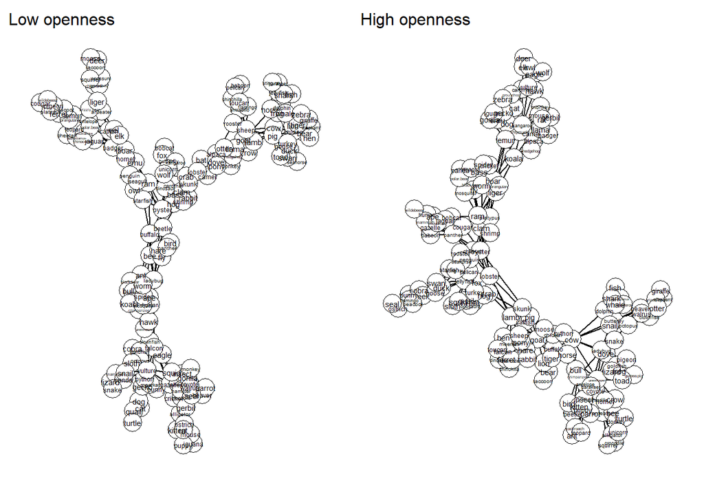

```r
# Finalize matrices so that each response has been given by at least two participants
low <- finalize(openness_low[,-1], minCase = 2)
high <- finalize(openness_high[,-1], minCase = 2)

# Equate the responses across the networks
eq <- equate(low, high)
equate_low <- eq$low
equate_high <- eq$high

# Compute Pearson's correlations for the 'low' and 'high' equated binary matrices
cor_low <- similarity(equate_low, method = "cor")
cor_high <- similarity(equate_high, method = "cor")

# Estimate networks for 'low' and 'high' openness groups
net_low <- TMFG(cor_low)
net_high <- TMFG(cor_high)

# Visualizing and comparing networks
compare_nets(net_low, net_high, title = list("Low openness", "High openness"), config = "spring", weighted = FALSE)
```

##### *3.7 Comparing VF networks in two groups with random networks*

Sixth, VF networks were compared against random networks with the same number of nodes and links as well as preserved number of connections to each node.

```r
# Comparing VF networks with random networks
rand.test <- randnet.test(net.low, net.high, iter = 1000, cores = 8)

# Results summary
rand.test
```

```
## $net.low
##      net.low (p-value) M.rand SD.rand
## ASPL                 0 2.7212  0.0185
## CC                   0 0.1356  0.0121
## Q                    0 0.3587  0.0079
##
## $net.high
##      net.high (p-value) M.rand SD.rand
## ASPL                  0 2.6211  0.0177
## CC                    0 0.1772  0.0130
## Q                     0 0.3495  0.0076
```

##### *3.8 Bootstrap network analysis (ASPL, CC, and Q)*

After verifying that there are statistically significant differences between VF networks and random networks, we proceeded with bootstrap network analysis to get accurate values of large-scale parameters of network’s structure for each group. The latter include (a) average shortest path length (ASPL), (b) clustering coefficient (CC), and (c) maximum modularity coefficient (Q).

```r
# Compute bootstrap network analysis
# ASPL = average shortest path length
# CC = clustering coefficient
# Q = maximum modularity coefficient
boot <- bootSemNeT(openness_low, openness_high, method = "TMFG", type = "case", iter = 1000, sim = "cosine", cores = 8)
```

##### *3.9 Statistical comparison of two networks on ASPL, CC, and Q (t-test)*

Lastly, network parameters were compared between two groups using t-test for independent samples.

```r
# Perform t-tests on bootstrap results
tests <- test.bootSemNeT(boot)

# Results summary
tests
```

```
## $Case
##        df t-statistic p-value lower.ci upper.ci     d Mean1   SD1 Mean2   SD2
## ASPL 1998      19.594  < .001     0.17    0.207 0.876 3.433 0.238 3.245  0.19
## CC   1998     -15.984  < .001   -0.007   -0.005 0.715 0.727 0.009 0.733 0.008
## Q    1998      12.714  < .001    0.008    0.011 0.569 0.662 0.017 0.652 0.018
##                               Direction
## ASPL openness_low(1) > (2)openness_high
## CC   openness_low(1) < (2)openness_high
## Q    openness_low(1) > (2)openness_high
```

##### *3.10 Visualizing mean values for ASPL, CC, and Q*

Graphical representation of mean differences for ASPL, CC, and Q between groups.

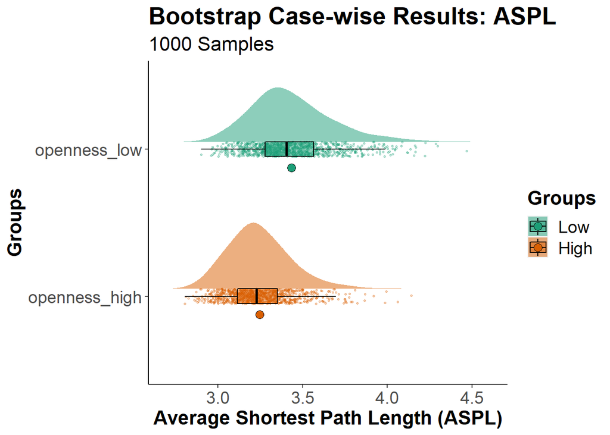

```r
# Visualize plots of mean values for ASPL, CC, and Q
plots <- plot(boot, groups = c("Low","High"),measures = c("ASPL", "CC", "Q"))

# ASPL graph
plots$aspl
```

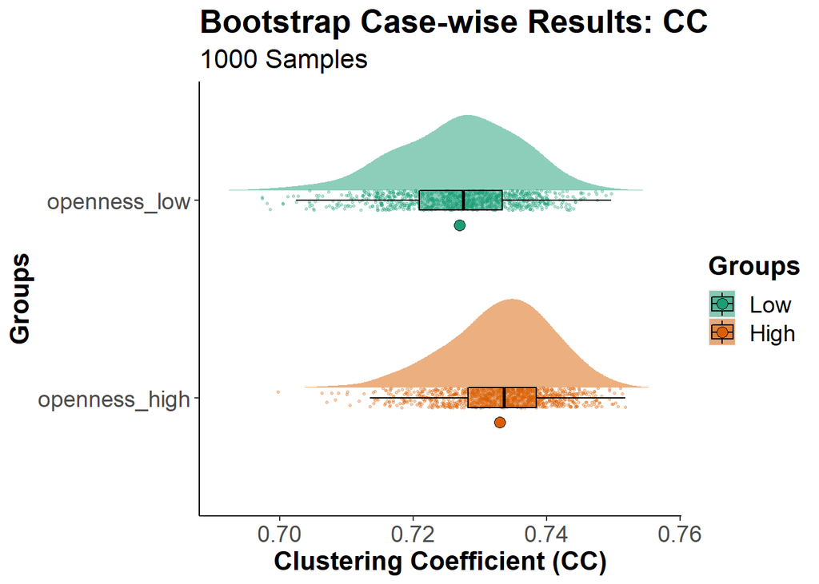

```r
# CC graph
plots$cc
```

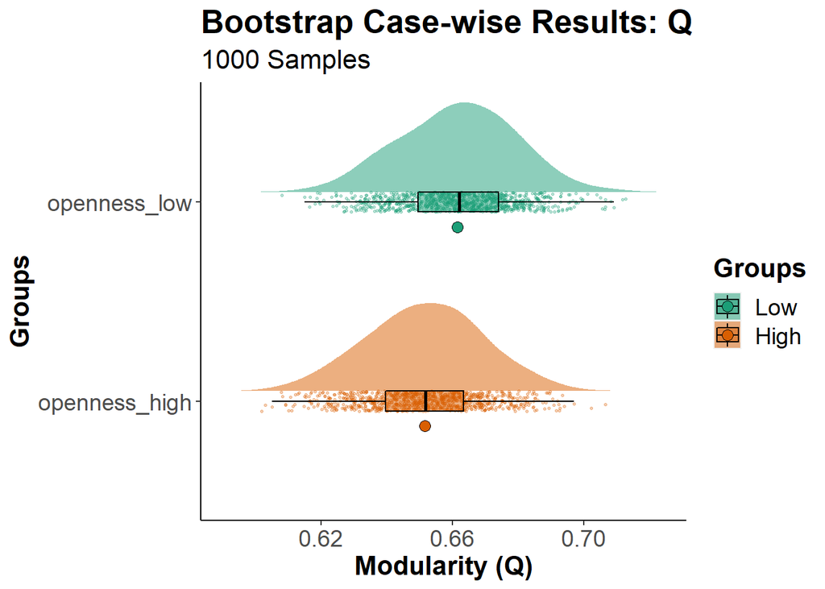

```r
# CC graph
plots$q
```

**Conclusion:** I conducted statistical analysis to verify that there are differences in the structure of semantic memory between groups with high vs. low level of openness to experience. In particular, it was hypothesized that high openness to experience group’s network would be more interconnected than the low openness to experience group’s network. To test the hypothesis, we compared three macro-level network characteristics between groups with high and low openness to experience. That is, (a) average shortest path length (ASPL), (b) clustering coefficient (CC), and (c) maximum modularity coefficient (Q). Results showed that group with low openness to experience compared to group with high openness to experience had higher ASPL, lower CC, and higher Q. Therefore, our analysis corroborated the claim provided in the original publication: *The group with high openness to experience compared to the group with low openness to experience had better connected structure of semantic memory*